# CA2

Name: Pranjal Prathap Bavikai

Admin number: 2228396

Form Class: DIT/FT/2A/02

PDS Class: EL/EP0302/FT/04

# CA2

# Title of Data Analysis

The Impact of Education on Intelligence and Happiness: Data Analysis

# List of URLs of dataset

- https://data.gov.sg/dataset/graduate-employment-survey-ntu-nus-sit-smu-suss-sutd
- https://data.gov.sg/dataset/government-recurrent-expenditure-on-education-per-student
- https://data.gov.sg/dataset/universities-intake-enrolment-and-graduates-by-course
- https://worldpopulationreview.com/country-rankings/average-iq-by-country
- https://www.kaggle.com/datasets/mathurinache/world-happiness-report
- https://www.kaggle.com/datasets/tmishinev/world-country-gdp-19602021
- https://www.kaggle.com/datasets/luxoloshilofunde/total-government-expenditure-on-education

# Import libraries

```python
import numpy as np
import matplotlib.pyplot as plt
import pandas as pd
import seaborn as sns
```

# Import data file

```python
# educational dataset
graduate_employment_survey_ntu_nus_sit_smu_suss_sutd = pd.read_csv('./graduate-employment-survey-ntu-nus-sit-smu-suss-sutd/graduate-employment-survey-ntu-nus-sit-smu-suss-sutd.csv', encoding='latin-1')
government_recurrent_expenditure_on_education_per_student = pd.read_csv('./government-recurrent-expenditure-on-education-per-student/government-recurrent-expenditure-on-education-per-student.csv', encoding='latin-1')
universities_intake_enrolment_and_graduates_by_course = pd.read_csv('./universities-intake-enrolment-and-graduates-by-course/universities-intake-enrolment-and-graduates-by-course.csv', encoding='latin-1')
# iq dataset
average_iq_by_country_2023 = pd.read_csv('./average_iq_by_country_2023/average_iq_by_country_2023.csv')
# world happiness report
world_happiness_2019 = pd.read_csv("./world_happiness_report/2019.csv")
world_happiness_2020 = pd.read_csv("./world_happiness_report/2020.csv")
world_happiness_2021 = pd.read_csv("./world_happiness_report/2021.csv")
world_happiness_2022 = pd.read_csv("./world_happiness_report/2022.csv")
# total government expenditure on education
total_government_expenditure_on_education_gdp = pd.read_csv("./total-government-expenditure-on-education-gdp/total-government-expenditure-on-education-gdp.csv")
# World, Region, Country GDP/GDP per capita
world_country_gdp_usd = pd.read_csv("./world_country_gdp_usd/world_country_gdp_usd.csv")
```

# Function for Text-based Analysis

```python
def text_analysis(dataset, dataset_name):
    print(f"\nThis is the shape of the dataset {dataset_name}:")
    print(dataset.shape)

    print(f"\nThis is the index of the dataset {dataset_name}:")
    print(dataset.index)

    print(f"\nThese are the columns in the dataset {dataset_name}:")
    print(dataset.columns)

    print(f"\nThe total number of non-NA values in the dataset {dataset_name}:")
    print(dataset.notna().sum())

    print(f"\nA summary of the dataset {dataset_name} is shown below:")
    print(dataset.info())

    print(f"\nA descriptive statistical summary of the dataset {dataset_name} is shown below:")
    print(dataset.describe())
```

# Graduate Employment Survey

```python
text_analysis(graduate_employment_survey_ntu_nus_sit_smu_suss_sutd, "graduate_employment_survey_ntu_nus_sit_smu_suss_sutd")
```

```
This is the shape of the dataset graduate_employment_survey_ntu_nus_sit_smu_suss_sutd:
(1121, 12)

This is the index of the dataset graduate_employment_survey_ntu_nus_sit_smu_suss_sutd:
RangeIndex(start=0, stop=1121, step=1)

These are the columns in the dataset graduate_employment_survey_ntu_nus_sit_smu_suss_sutd:
Index(['year', 'university', 'school', 'degree', 'employment_rate_overall',
       'employment_rate_ft_perm', 'basic_monthly_mean', 'basic_monthly_median',
       'gross_monthly_mean', 'gross_monthly_median',
       'gross_mthly_25_percentile', 'gross_mthly_75_percentile'],
      dtype='object')

The total number of non-NA values in the dataset graduate_employment_survey_ntu_nus_sit_smu_suss_sutd:
year                         1121
university                   1121
school                       1121
degree                       1121
employment_rate_overall      1121
employment_rate_ft_perm      1121
basic_monthly_mean           1121
basic_monthly_median         1121
gross_monthly_mean           1121
gross_monthly_median         1121
gross_mthly_25_percentile    1121
gross_mthly_75_percentile    1121
dtype: int64

A summary of the dataset graduate_employment_survey_ntu_nus_sit_smu_suss_sutd is shown below:
<class 'pandas.core.frame.DataFrame'>
RangeIndex: 1121 entries, 0 to 1120
Data columns (total 12 columns):
 #   Column                     Non-Null Count  Dtype
---  ------                     --------------  -----
 0   year                       1121 non-null   int64
 1   university                 1121 non-null   object
 2   school                     1121 non-null   object
 3   degree                     1121 non-null   object
 4   employment_rate_overall    1121 non-null   object
 5   employment_rate_ft_perm    1121 non-null   object
 6   basic_monthly_mean         1121 non-null   object
 7   basic_monthly_median       1121 non-null   object
 8   gross_monthly_mean         1121 non-null   object
 9   gross_monthly_median       1121 non-null   object
 10  gross_mthly_25_percentile  1121 non-null   object
 11  gross_mthly_75_percentile  1121 non-null   object
dtypes: int64(1), object(11)
memory usage: 105.2+ KB
None

A descriptive statistical summary of the dataset graduate_employment_survey_ntu_nus_sit_smu_suss_sutd is shown below:
              year
count  1121.000000
mean   2017.303301
std       2.492646
min    2013.000000
25%    2015.000000
50%    2017.000000
75%    2019.000000
max    2021.000000
```

# Nature Of The Dataset:

The CSV file "graduate-employment-survey-ntu-nus-sit-smu-suss-sutd" contains data on the employment outcomes of graduates from the six autonomous universities in Singapore (NUS, NTU, SMU, SUTD, SIT, and SUSS). The data includes the following columns:

- Year: The year in which the graduate graduated.
- University: The university from which the graduate graduated.
- School: The school within the university from which the graduate graduated.
- Degree: The degree that the graduate graduated with.
- Employment_rate_overall: The overall employment rate of graduates from the university.
- Employment_rate_ft_perm: The full-time permanent employment rate of graduates from the university.
- Basic_monthly_mean: The mean basic monthly salary of graduates from the university.
- Basic_monthly_median: The median basic monthly salary of graduates from the university.
- Gross_monthly_mean: The mean gross monthly salary of graduates from the university.
- Gross_monthly_median: The median gross monthly salary of graduates from the university.
- Gross_mthly_25_percentile: The 25th percentile of the gross monthly salaries of graduates from the university.
- Gross_mthly_75_percentile: The 75th percentile of the gross monthly salaries of graduates from the university.

The dataset contains a total of 1121 rows of data. The data is relatively clean and well-formatted. However, there are a few peculiarities that should be noted.

- The data does not include information on the gender of the graduates. This information would be useful for understanding the differences in employment outcomes between male and female graduates.
- The data does not include information on the race of the graduates. This information would also be useful for understanding the differences in employment outcomes between different racial groups.
- The data does not include information on the undergraduate GPA of the graduates. This information would be useful for understanding the relationship between undergraduate GPA and employment outcomes.
- It is also to be noted that the number of graduates surveyed for each university is different, NTU & NUS graduates accounted for most of the surveys conducted.

I analyzed the dataset using the following steps:

1. I imported the data into a Python Pandas DataFrame.
2. I performed a statistical analysis of the data, including calculating the mean, range of the employment rates, basic monthly salaries.
3. I created visualizations of the data, such as line charts, bar charts, box plots, and scatterplots.
4. I interpreted the results of the analysis to identify trends and patterns in the data.

# What is the employment rates of graduates from various universities in Singapore?

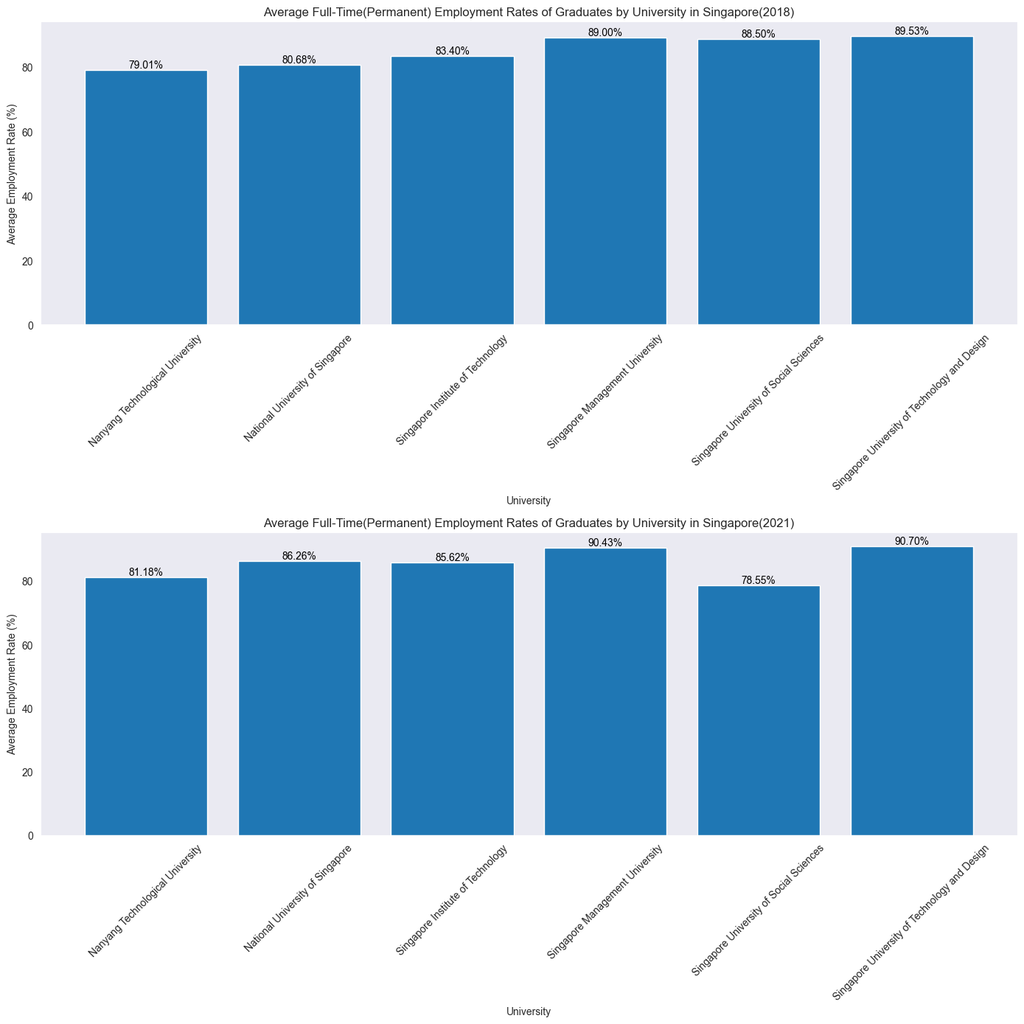

```python
# Clean the data and convert numeric columns to appropriate data types
numeric_columns = ['employment_rate_overall', 'employment_rate_ft_perm', 'basic_monthly_mean', 'basic_monthly_median', 'gross_monthly_mean', 'gross_monthly_median', 'gross_mthly_25_percentile', 'gross_mthly_75_percentile']
graduate_employment_survey_ntu_nus_sit_smu_suss_sutd[numeric_columns] = graduate_employment_survey_ntu_nus_sit_smu_suss_sutd[numeric_columns].apply(pd.to_numeric, errors='coerce')

# Drop rows with NaN values in the 'employment_rate_ft_perm' column
cleaned_data_ft = graduate_employment_survey_ntu_nus_sit_smu_suss_sutd.dropna(subset=['employment_rate_ft_perm'])

# Group the data by university and calculate the average employment rate for each university
university_employment_rates_2018 = cleaned_data_ft.loc[cleaned_data_ft['year'] == 2018].groupby('university')['employment_rate_ft_perm'].mean()
university_employment_rates_2021 = cleaned_data_ft.loc[cleaned_data_ft['year'] == 2021].groupby('university')['employment_rate_ft_perm'].mean()

# Plot the bar graph
plt.figure(figsize=(14, 14))

# full-time data for 2018
plt.subplot(2, 1, 1)
bars = plt.bar(university_employment_rates_2018.index, university_employment_rates_2018.values)
plt.xlabel('University')
plt.ylabel('Average Employment Rate (%)')
plt.title('Average Full-Time(Permanent) Employment Rates of Graduates by University in Singapore(2018)')
plt.xticks(rotation=45)
plt.tight_layout()
plt.grid()
# Add the values of each bar to the corresponding bars
for bar in bars:
    height = bar.get_height()
    plt.text(bar.get_x() + bar.get_width() / 2, height, f'{height:.2f}%',
             ha='center', va='bottom', fontsize=10, color='black')

# full-time data for 2021
plt.subplot(2, 1, 2)
bars = plt.bar(university_employment_rates_2021.index, university_employment_rates_2021.values)
plt.xlabel('University')
plt.ylabel('Average Employment Rate (%)')
plt.title('Average Full-Time(Permanent) Employment Rates of Graduates by University in Singapore(2021)')
plt.xticks(rotation=45)
plt.tight_layout()
plt.grid()
# Add the values of each bar to the corresponding bars
for bar in bars:
    height = bar.get_height()
    plt.text(bar.get_x() + bar.get_width() / 2, height, f'{height:.2f}%',
             ha='center', va='bottom', fontsize=10, color='black')
plt.show()
```

# What is the trend of the mean basic monthly salary over the years for local universities in Sinagpore ?

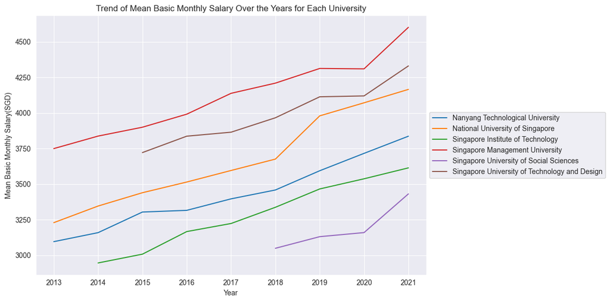

```python
# Clean the data and convert numeric columns to appropriate data types
numeric_columns = ['employment_rate_overall', 'employment_rate_ft_perm', 'basic_monthly_mean', 'basic_monthly_median', 'gross_monthly_mean', 'gross_monthly_median', 'gross_mthly_25_percentile', 'gross_mthly_75_percentile']
graduate_employment_survey_ntu_nus_sit_smu_suss_sutd[numeric_columns] = graduate_employment_survey_ntu_nus_sit_smu_suss_sutd[numeric_columns].apply(pd.to_numeric, errors='coerce')

# Drop rows with NaN values in the 'basic_monthly_mean' column
cleaned_data = graduate_employment_survey_ntu_nus_sit_smu_suss_sutd.dropna(subset=['basic_monthly_mean'])

# Group the data by university and year, and calculate the mean salary for each university in each year
grouped_data = cleaned_data.groupby(["university", "year"])["basic_monthly_mean"].mean().reset_index()

# Create a line chart to show the trend of mean salaries over the years for each university
plt.figure(figsize=(12, 6))

universities = grouped_data["university"].unique()

for university in universities:
    data_by_university = grouped_data[grouped_data["university"] == university]
    plt.plot(data_by_university["year"], data_by_university["basic_monthly_mean"], label=university)

plt.xlabel('Year')
plt.ylabel('Mean Basic Monthly Salary(SGD)')
plt.title('Trend of Mean Basic Monthly Salary Over the Years for Each University')
plt.legend(loc='center left', bbox_to_anchor=(1, 0.5))
plt.grid(True)
plt.tight_layout()
plt.show()
```

From the line chart, it shows the Trend of Mean Basic Monthly Salary Over the Years for Each University. It is evident that there is a notable relationship between the passage of time and the increase in mean basic monthly salary for all universities. There is also a steep increase in basic monthly salary between 2018-2019 for NUS(around SGD3700 to around SGD4000), 2020-2021 for SMU(around SGD4300 to around SGD4600) & SUSS(around SGD3200 to around SGD3450). In 2021, the lowest basic monthly salary would be around SGD3450 for SUSS and the highest would be be around SGD4600 for SMU.

# How does the mean basic monthly salary correlate with the employment rate?

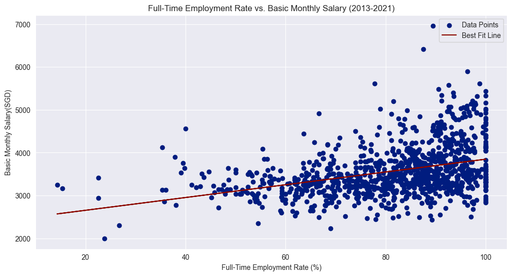

```python
# Clean the data and convert numeric columns to appropriate data types
numeric_columns = ['employment_rate_overall', 'employment_rate_ft_perm', 'basic_monthly_mean', 'basic_monthly_median', 'gross_monthly_mean', 'gross_monthly_median', 'gross_mthly_25_percentile', 'gross_mthly_75_percentile']
graduate_employment_survey_ntu_nus_sit_smu_suss_sutd[numeric_columns] = graduate_employment_survey_ntu_nus_sit_smu_suss_sutd[numeric_columns].apply(pd.to_numeric, errors='coerce')

# Drop rows with NaN values in the 'basic_monthly_mean' & 'employment_rate_ft_perm' column
cleaned_data = graduate_employment_survey_ntu_nus_sit_smu_suss_sutd.dropna(subset=['basic_monthly_mean', 'employment_rate_ft_perm'])

# Basic monthly salary vs. employment rate
plt.figure(figsize=(12, 6))
plt.scatter(cleaned_data['employment_rate_ft_perm'], cleaned_data['basic_monthly_mean'], marker='o', c='b', label='Data Points')

# Calculate the best-fit line (linear regression)
coefficients = np.polyfit(cleaned_data['employment_rate_ft_perm'], cleaned_data['basic_monthly_mean'], 1)
poly_function = np.poly1d(coefficients)
x_values = cleaned_data['employment_rate_ft_perm']
y_fit = poly_function(x_values)

# Plot the best-fit line
plt.plot(x_values, y_fit, color='r', label='Best Fit Line')

plt.xlabel('Full-Time Employment Rate (%)')
plt.ylabel('Basic Monthly Salary(SGD)')
plt.title('Full-Time Employment Rate vs. Basic Monthly Salary (2013-2021)')
plt.legend()
plt.grid(True)
plt.show()
```

When the demand for labor is high, the basic monthly salary is high. When the demand for labor is low, the basic monthly salary is low.

# What is the spread of data for mean basic monthly salary by University ?

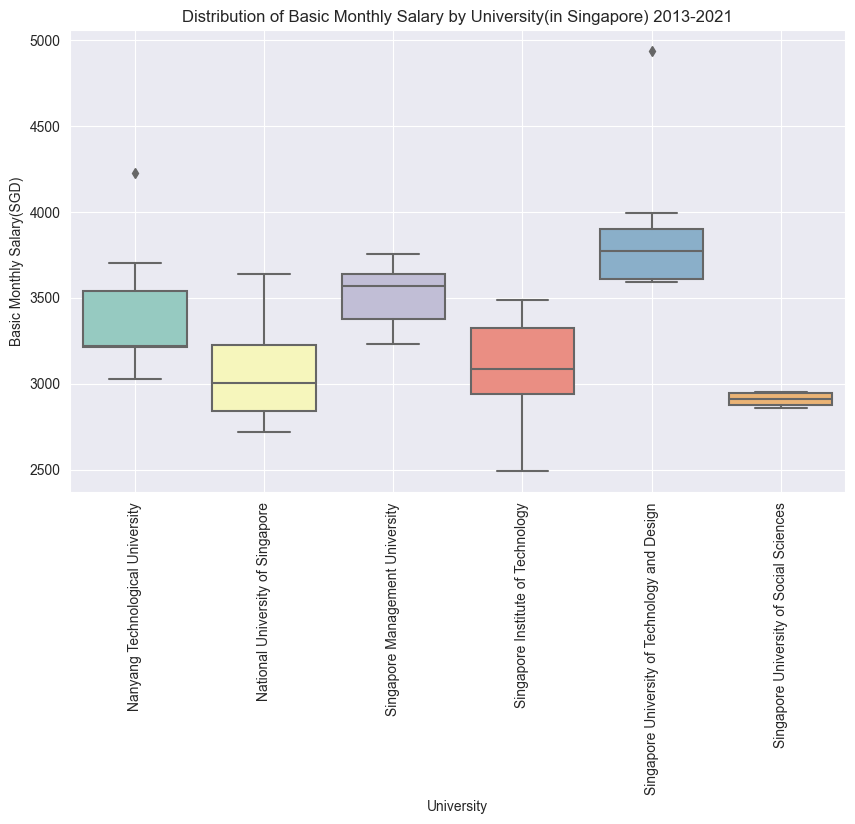

```python
# Clean the data and convert numeric columns to appropriate data types
numeric_columns = ['employment_rate_overall', 'employment_rate_ft_perm', 'basic_monthly_mean', 'basic_monthly_median', 'gross_monthly_mean', 'gross_monthly_median', 'gross_mthly_25_percentile', 'gross_mthly_75_percentile']
graduate_employment_survey_ntu_nus_sit_smu_suss_sutd[numeric_columns] = graduate_employment_survey_ntu_nus_sit_smu_suss_sutd[numeric_columns].apply(pd.to_numeric, errors='coerce')

# Drop rows with NaN values in the 'basic_monthly_mean' column
cleaned_data = graduate_employment_survey_ntu_nus_sit_smu_suss_sutd.dropna(subset=['basic_monthly_mean'])

# Remove duplicates based on 'year' and 'university' columns
cleaned_data = cleaned_data.drop_duplicates(subset=['year', 'university'])

# Boxplot: Distribution of basic monthly salary by university
plt.figure(figsize=(10, 6))
sns.boxplot(x='university', y='basic_monthly_mean', data=cleaned_data, palette='Set3')
plt.xlabel('University')
plt.xticks(rotation=90)
plt.ylabel('Basic Monthly Salary(SGD)')
plt.title('Distribution of Basic Monthly Salary by University(in Singapore) 2013-2021')
plt.grid(True)
plt.show()
```

From the boxplot, it shows the distribution of the basic monthly salary across various universities in Singapore. NTU & SUTD has outliers. The university with lowest variance is SUSS. The universities with a huge variance are NUS & SIT.

# Insights gained from analysing the data

I have analyzed the data in the CSV file "graduate-employment-survey-ntu-nus-sit-smu-suss-sutd". Here are some insights I have gained:

Based on my analysis, I have the following conclusions and recommendations:

- The strong economic growth in Singapore is likely to continue in the coming years, which will lead to an increase in the demand for skilled workers. This will in turn lead to an increase in the average employment rate and basic monthly salary of graduates from the six autonomous universities in Singapore.
- The government's efforts to improve the job market for graduates are also likely to continue in the coming years. This will help to ensure that graduates from the six autonomous universities in Singapore are able to find good jobs and earn competitive salaries.
- Students who are considering attending one of the six autonomous universities in Singapore should be aware of the different average basic monthly salaries across the universities. This will help them to choose a university that is a good fit for their financial goals.

Here are some additional insights that could be gained from the data:

- SUSS has the lowest variance in the distribution of the basic monthly salary. This means that the basic monthly salaries of graduates from SUSS are more evenly distributed.
- NUS and SIT have a huge variance in the distribution of the basic monthly salary. This means that there are a large number of graduates from these universities who are earning significantly more than the average, and a large number of graduates who are earning significantly less than the average.
- The analysis of the dataset provides valuable insights into the employment outcomes of graduates from the six autonomous universities in Singapore. The findings of the analysis can be used by prospective students, parents, and employers to make informed decisions about education and career planning.

# Singapore Government Recurrent Expenditure on Education Per Student

```python
text_analysis(government_recurrent_expenditure_on_education_per_student, "government_recurrent_expenditure_on_education_per_student")
```

```
This is the shape of the dataset government_recurrent_expenditure_on_education_per_student:
(216, 3)

This is the index of the dataset government_recurrent_expenditure_on_education_per_student:
RangeIndex(start=0, stop=216, step=1)

These are the columns in the dataset government_recurrent_expenditure_on_education_per_student:
Index(['year', 'type_of_educational_institution', 'expenditure_per_student'], dtype='object')

The total number of non-NA values in the dataset government_recurrent_expenditure_on_education_per_student:
year                               216
type_of_educational_institution    216
expenditure_per_student            216
dtype: int64

A summary of the dataset government_recurrent_expenditure_on_education_per_student is shown below:
<class 'pandas.core.frame.DataFrame'>
RangeIndex: 216 entries, 0 to 215
Data columns (total 3 columns):
 #   Column                           Non-Null Count  Dtype
---  ------                           --------------  -----
 0   year                             216 non-null    int64
 1   type_of_educational_institution  216 non-null    object
 2   expenditure_per_student          216 non-null    int64
dtypes: int64(2), object(1)
memory usage: 5.2+ KB
None

A descriptive statistical summary of the dataset government_recurrent_expenditure_on_education_per_student is shown below:
              year  expenditure_per_student
count   216.000000               216.000000
mean   2003.500000             10030.685185
std      10.412425              5508.035846
min    1986.000000              1404.000000
25%    1994.750000              5204.000000
50%    2003.500000              9607.500000
75%    2012.250000             14463.750000
max    2021.000000             22186.000000
```

# Nature Of The Dataset:

- Year: The year in which the expenditure was made.
- Type of educational institution: The type of educational institution, such as primary school, secondary school, polytechnic, or university.
- Expenditure per student: The amount of government recurrent expenditure per student in that institution in that year.

The dataset contains a total of 216 rows of data. The data is relatively clean and well-formatted. However, there are a few peculiarities that should be noted.

- The data does not include information on the number of students enrolled in each type of educational institution. This information would be useful for understanding the relative impact of the government's expenditure on each type of institution.

I analyzed the dataset using the following steps:

1. I imported the data into a Python Numpy DataFrame.
2. I performed a statistical analysis of the data, including calculating the mean, of the expenditure per student by type of educational institution.
3. I created visualizations of the data, such as line chart, bar graph, pie chart and boxplots.
4. I interpreted the results of the analysis to identify trends and patterns in the data.

# What is the average Government Recurrent Expenditure on Education Per Student across different educational institutions ?

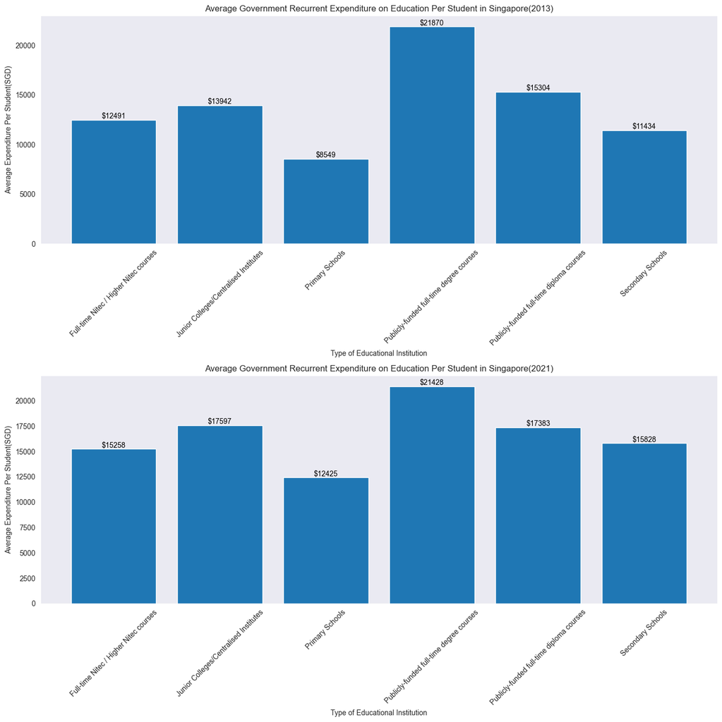

```python
# Group the data by university and calculate the average employment rate for each university
govt_expenditure_2013 = government_recurrent_expenditure_on_education_per_student.loc[government_recurrent_expenditure_on_education_per_student['year'] == 2013].groupby('type_of_educational_institution')['expenditure_per_student'].mean()
govt_expenditure_2021 = government_recurrent_expenditure_on_education_per_student.loc[government_recurrent_expenditure_on_education_per_student['year'] == 2021].groupby('type_of_educational_institution')['expenditure_per_student'].mean()

# Plot the bar graph
plt.figure(figsize=(14, 14))

# full-time data for 2013
plt.subplot(2, 1, 1)
bars = plt.bar(govt_expenditure_2013.index, govt_expenditure_2013.values)
plt.xlabel('Type of Educational Institution')
plt.ylabel('Average Expenditure Per Student(SGD)')
plt.title('Average Government Recurrent Expenditure on Education Per Student in Singapore(2013)')
plt.xticks(rotation=45)
plt.tight_layout()
plt.grid()
# Add the values of each bar to the corresponding bars
for bar in bars:
    height = bar.get_height()
    plt.text(bar.get_x() + bar.get_width() / 2, height, f'${height:.0f}',
             ha='center', va='bottom', fontsize=10, color='black')

# full-time data for 2021
plt.subplot(2, 1, 2)
bars = plt.bar(govt_expenditure_2021.index, govt_expenditure_2021.values)
plt.xlabel('Type of Educational Institution')
plt.ylabel('Average Expenditure Per Student(SGD)')
plt.title('Average Government Recurrent Expenditure on Education Per Student in Singapore(2021)')
plt.xticks(rotation=45)
plt.tight_layout()
plt.grid()
# Add the values of each bar to the corresponding bars
for bar in bars:
    height = bar.get_height()
    plt.text(bar.get_x() + bar.get_width() / 2, height, f'${height:.0f}',
             ha='center', va='bottom', fontsize=10, color='black')
plt.show()
```

From the bar graph, it shows the Average Government Recurrent Expenditure on Education Per Student. The highest average government expenditure on education per student for a educational institution in 2013 & 2021 would be Publicly-funded full-time degree courses(SGD21870 & SGD21428 respectively). The lowest average government expenditure on education per student for a educational institution in 2013 & 2021 would be Primary schools(SGD8549 & SGD12425 respectively). It can also be noted that all educational institutions have increased expenditure on education per student from 2013 to 2021, with the exception of Publicly-funded full-time degree courses with an expenditure per student of SGD21870 in 2013 and SGD21428 in 2021.

# How has the governments expenditure on education per student changed over the years across various Tertiary Educational Institutions ?

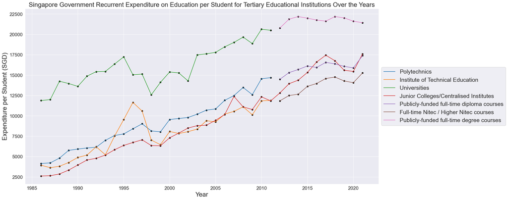

```python
tertiary = ['Polytechnics', 'Institute of Technical Education', 'Universities', 'Junior Colleges/Centralised Institutes', 'Publicly-funded full-time diploma courses', 'Full-time Nitec / Higher Nitec courses', 'Publicly-funded full-time degree courses']
grouped_by_tertiary = government_recurrent_expenditure_on_education_per_student[government_recurrent_expenditure_on_education_per_student['type_of_educational_institution'].isin(tertiary)]

plt.figure(figsize=(20, 10))

for institution in tertiary:
    institution_data = grouped_by_tertiary[grouped_by_tertiary['type_of_educational_institution'] == institution]
    sns.lineplot(data=institution_data, x='year', y='expenditure_per_student', label=institution)
    sns.scatterplot(x='year', y='expenditure_per_student', data=institution_data, color='black')

plt.xlabel('Year',fontsize=20)
plt.ylabel('Expenditure per Student (SGD)',fontsize=20)
plt.title('Singapore Government Recurrent Expenditure on Education per Student for Tertiary Educational Institutions Over the Years',fontsize=20)
plt.legend(loc='center left', bbox_to_anchor=(1, 0.5), fontsize=18)
plt.grid(True)
plt.xticks(fontsize=15)
plt.yticks(fontsize=15)
plt.show()
```

From the line chart, it shows the Singapore Government Recurrent Expenditure on Education per Student for Tertiary Educational Institutions Over the Years. It is evident that there is a notable relationship between the passage of time and the increase in expenditure per student for all educational institutions. There is also a steep increase in expenditure per student between 1993-1996 for ITE(around SGD5000 to around SGD12000). In 2021, the lowest expenditure per student would be around SGD15000 for Full-time Nitec / Higher Nitec courses and the highest would be be around SGD21250 for Publicly-funded full-time degree courses.

# What is the spread of data for Government Recurrent Expenditure on Education Per Student by Type of Tertiary Educational Institutions ?

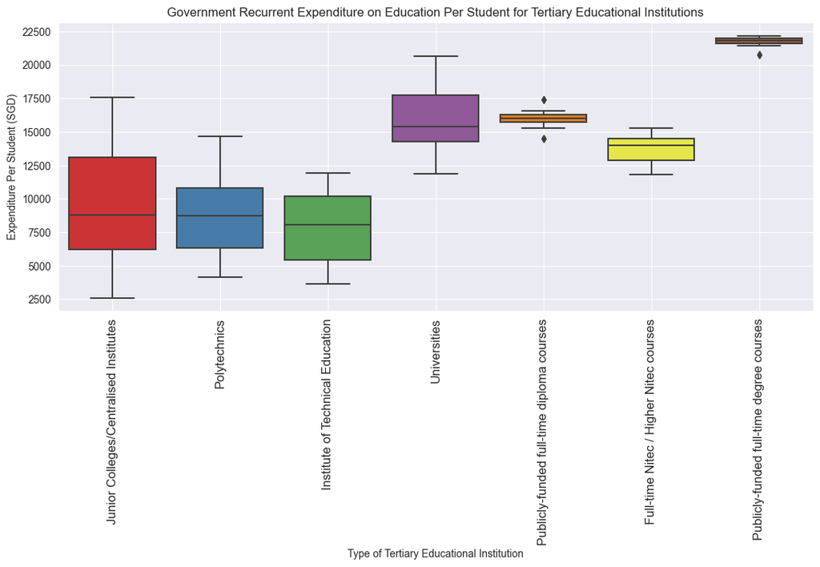

```python
tertiary = ['Polytechnics', 'Institute of Technical Education', 'Universities', 'Junior Colleges/Centralised Institutes', 'Publicly-funded full-time diploma courses', 'Full-time Nitec / Higher Nitec courses', 'Publicly-funded full-time degree courses']
grouped_by_tertiary = government_recurrent_expenditure_on_education_per_student[government_recurrent_expenditure_on_education_per_student['type_of_educational_institution'].isin(tertiary)]

# Make a boxplot for each type of educational institution in Singapore
plt.figure(figsize=(13, 5))
sns.boxplot(x='type_of_educational_institution', y='expenditure_per_student', data=grouped_by_tertiary, palette='Set1')
plt.xticks(rotation=90, size=12)
plt.ylabel('Expenditure Per Student (SGD)')
plt.xlabel('Type of Tertiary Educational Institution')
plt.title("Government Recurrent Expenditure on Education Per Student for Tertiary Educational Institutions")
plt.grid(True)
```

From the boxplot, it shows the distribution of the expenditure per student across various type of educational institution. The variation in the amount of government expenditure on education per student per year is huge for Junior Colleges/Centralised Institutes, speard is from SGD2500-SGD17500. The variation in the amount of government expenditure on education per student per year is not as huge for Publicly-funded diploma courses, Higher Nitec and full-time degree courses. Although it is worth noting that Publicly-funded diploma courses and full-time degree courses have outliers.

# What is the distribution percentage wise of government expenditure per student across various tertiary educational institutions ?

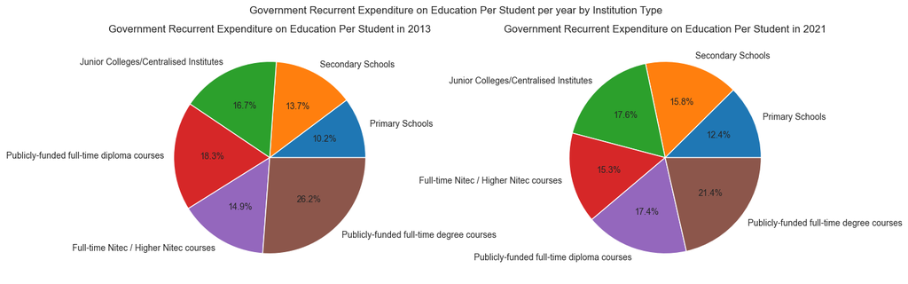

```python
govt_expenditure_sg_2013 = government_recurrent_expenditure_on_education_per_student[government_recurrent_expenditure_on_education_per_student['year'] == 2013]
govt_expenditure_sg_2021 = government_recurrent_expenditure_on_education_per_student[government_recurrent_expenditure_on_education_per_student['year'] == 2021]
fig, ax = plt.subplots(1, 2, figsize=(15, 5))
ax[0].set_title('Government Recurrent Expenditure on Education Per Student in 2013')
ax[1].set_title('Government Recurrent Expenditure on Education Per Student in 2021')

ax[0].pie(govt_expenditure_sg_2013['expenditure_per_student'], labels=govt_expenditure_sg_2013['type_of_educational_institution'], autopct='%1.1f%%')
ax[1].pie(govt_expenditure_sg_2021['expenditure_per_student'], labels=govt_expenditure_sg_2021['type_of_educational_institution'], autopct='%1.1f%%')

plt.suptitle('Government Recurrent Expenditure on Education Per Student per year by Institution Type')
```

# Insights gained from analysing the data

I have analyzed the data in the CSV file "government-recurrent-expenditure-on-education-per-student". Here are some insights I have gained:

Based on my analysis, I have the following conclusions and recommendations:

- The government's commitment to providing quality education to all Singaporeans is evident in the increasing government recurrent expenditure on education per student. This is a positive development, as it will help to ensure that all Singaporeans have the opportunity to reach their full potential.
- The government should continue to monitor the variation in the amount of government recurrent expenditure on education per student per year for junior colleges/centralised institutes. This is to ensure that these institutions are able to provide quality education to all students, regardless of their socioeconomic background.
- The government should continue to work towards making education more accessible to all Singaporeans. This could be done by increasing the number of scholarships and bursaries available, and by making it easier for students from low-income families to access loans.

Here are some additional insights that could be gained from the data:

- The percentage of government recurrent expenditure on education per student that is allocated to each type of educational institution has become more evenly distributed over time. This is likely due to the government's efforts to improve access to education for all Singaporeans, regardless of their socioeconomic background.
- I believe that the data in this dataset can be used to inform policy decisions about education funding in Singapore. For example, the data could be used to argue for increased funding for education, or to identify areas where funding could be more effectively targeted.
- Overall, I believe that the data in this dataset is a valuable resource for understanding the government's investment in education in Singapore.

# Universities - Intake, Enrolment and Graduates by Course

```python
text_analysis(universities_intake_enrolment_and_graduates_by_course, "universities_intake_enrolment_and_graduates_by_course")
```

```
This is the shape of the dataset universities_intake_enrolment_and_graduates_by_course:
(510, 6)

This is the index of the dataset universities_intake_enrolment_and_graduates_by_course:
RangeIndex(start=0, stop=510, step=1)

These are the columns in the dataset universities_intake_enrolment_and_graduates_by_course:
Index(['year', 'sex', 'course', 'intake', 'enrolment', 'graduates'], dtype='object')

The total number of non-NA values in the dataset universities_intake_enrolment_and_graduates_by_course:
year         510
sex          510
course       510
intake       510
enrolment    510
graduates    510
dtype: int64

A summary of the dataset universities_intake_enrolment_and_graduates_by_course is shown below:
<class 'pandas.core.frame.DataFrame'>
RangeIndex: 510 entries, 0 to 509
Data columns (total 6 columns):
 #   Column     Non-Null Count  Dtype
---  ------     --------------  -----
 0   year       510 non-null    int64
 1   sex        510 non-null    object
 2   course     510 non-null    object
 3   intake     510 non-null    int64
 4   enrolment  510 non-null    int64
 5   graduates  510 non-null    int64
dtypes: int64(4), object(2)
memory usage: 24.0+ KB
None

A descriptive statistical summary of the dataset universities_intake_enrolment_and_graduates_by_course is shown below:
              year       intake     enrolment    graduates
count   510.000000   510.000000    510.000000   510.000000
mean   2013.000000   856.500000   3052.150980   712.290196
std       4.903789  1046.964818   3753.460828   900.976873
min    2005.000000     0.000000      0.000000     0.000000
25%    2009.000000   185.000000    690.500000   146.250000
50%    2013.000000   383.500000   1394.000000   346.000000
75%    2017.000000  1240.750000   4494.000000  1062.250000
max    2021.000000  5255.000000  18366.000000  4621.000000
```

# Nature Of The Dataset:

The CSV file "Universities - Intake, Enrolment and Graduates by Course" contains data on the intake, enrolment, and graduates of different courses offered by universities in Singapore. The data includes the following columns:

- year: The year in which the course was offered.
- sex: The gender of the students enrolled in the course.
- course: The name of the course.
- intake: The number of students admitted to the course.
- enrolment: The number of students enrolled in the course.
- graduates: The number of students who graduated from the course.

The dataset contains a total of 510 rows of data. The data is relatively clean and well-formatted. However, there are a few peculiarities that should be noted.

- The data does not include information on the race of the students. This information would be useful for understanding the differences in enrollment and graduation rates between different racial groups.
- The data does not include information on the undergraduate GPA of the students. This information would be useful for understanding the relationship between undergraduate GPA and enrollment and graduation rates.
- Universities refers to National University of Singapore, Nanyang Technological University, Singapore Management University, Singapore Institute of Technology, Singapore University of Technology & Design and Singapore University of Social Sciences.
- Intake, enrolment and graduates figures refer to full-time first degree only.

I analyzed the dataset using the following steps:

1. I imported the data into a Python Pandas DataFrame.
2. I performed a statistical analysis of the data, including calculating the mean, median, and range of the intake, enrolment, and graduation rates.
3. I created visualizations of the data, such as line charts, bar charts, pie charts, and boxplots.
4. I interpreted the results of the analysis to identify trends and patterns in the data.

# What are the intakes for various courses offered in universities (Singapore)

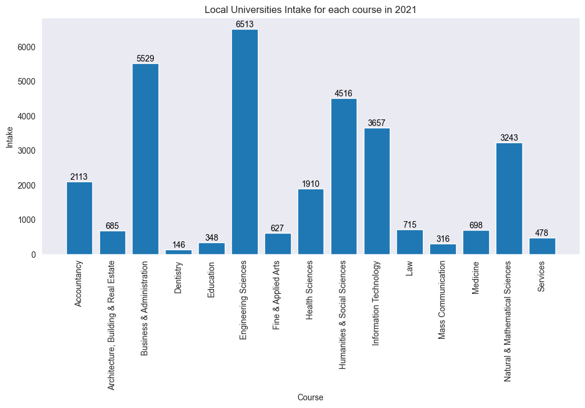

```python
# Drop rows with value '0'
cleaned_data = universities_intake_enrolment_and_graduates_by_course[universities_intake_enrolment_and_graduates_by_course['intake'] != 0]

# Group the data by course and calculate the intake for each course
universities_intake = cleaned_data.loc[cleaned_data['year'] == 2021].groupby('course')['intake'].sum().reset_index()

# Plot the bar graph
plt.figure(figsize=(10, 7))
bars = plt.bar(universities_intake['course'], universities_intake['intake'])
plt.xlabel('Course')
plt.ylabel('Intake')
plt.title('Local Universities Intake for each course in 2021')
plt.xticks(rotation=90)
plt.tight_layout()
plt.grid()
# Add the values of each bar to the corresponding bars
for bar in bars:
    height = bar.get_height()
    plt.text(bar.get_x() + bar.get_width() / 2, height, f'{height}',
             ha='center', va='bottom', fontsize=10, color='black')
plt.show()
```

From the bar graph, it shows the Intake for each course in 2021. The highest intake would be Engineering Sciences with 6513 students. The lowest intake would be Dentistry with 146 students.

# What are the Number of Graduates over Time for Different Courses?

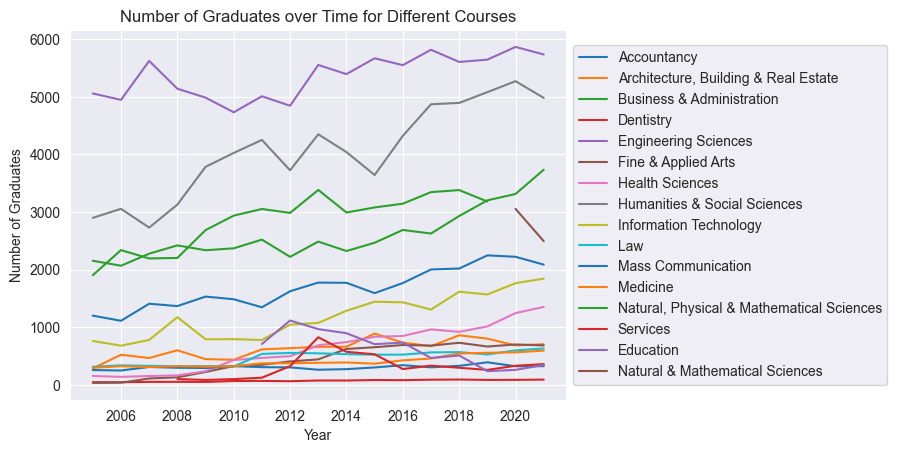

```python
# Drop rows with value '0'
cleaned_data = universities_intake_enrolment_and_graduates_by_course[universities_intake_enrolment_and_graduates_by_course['graduates'] != 0]

# Group the data by 'course' and 'year' to get the total graduates per year per course
grouped_data = cleaned_data.groupby(['course', 'year'])['graduates'].sum().reset_index()

# Create a line chart for each course
unique_courses = cleaned_data['course'].unique()
for course in unique_courses:
    data_for_course = grouped_data[grouped_data['course'] == course]
    plt.plot(data_for_course['year'], data_for_course['graduates'], label=course)

plt.xlabel('Year')
plt.ylabel('Number of Graduates')
plt.title('Number of Graduates over Time for Different Courses')
plt.legend(loc='center left', bbox_to_anchor=(1, 0.5), fontsize=10)
plt.show()
```

From the line chart, it shows the Number of Graduates over Time for Different Courses. It is evident that there is a notable relationship between the passage of time and the increase in the number of graduates. As the years progress, there is a consistent upward trend in the number of graduates. There is also a steep increase in graduates from humanities & social sciences from 2007-2011 as well as 2015-2017. Engineering Sciences has the highest number of gradduates over the years.

# What is the Number of Intakes over Time for Different Courses ?

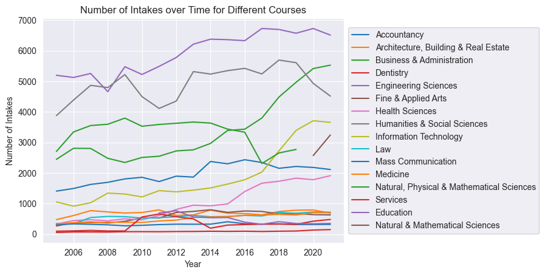

```python
# Drop rows with value '0'
cleaned_data = universities_intake_enrolment_and_graduates_by_course[universities_intake_enrolment_and_graduates_by_course['intake'] != 0]

# Group the data by 'course' and 'year' to get the total intake per year per course
grouped_data = cleaned_data.groupby(['course', 'year'])['intake'].sum().reset_index()

# Create a line chart for each course
unique_courses = cleaned_data['course'].unique()
for course in unique_courses:
    data_for_course = grouped_data[grouped_data['course'] == course]
    plt.plot(data_for_course['year'], data_for_course['intake'], label=course)

# Set chart labels and title
plt.xlabel('Year')
plt.ylabel('Number of Intakes')
plt.title('Number of Intakes over Time for Different Courses')
plt.legend(loc='center left', bbox_to_anchor=(1, 0.5), fontsize=10)
plt.show()
```

From the line chart, it shows the Number of Intakes over Time for Different Courses. It is evident that there is a notable upward trend in the number of intakes for Engineering Sciences from 2010 onwards. It is also shown that there has been a decline in intake for humanities from 2009-2011.

# What is the figure for the number of graduates from Local Universities over the years?

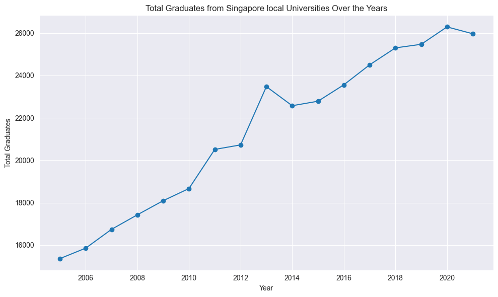

```python
# Drop rows with value '0'
cleaned_data = universities_intake_enrolment_and_graduates_by_course[universities_intake_enrolment_and_graduates_by_course['graduates'] != 0]

# Group data by year and calculate the total graduates for each year
total_graduates_per_year = cleaned_data.groupby('year')['graduates'].sum()

# Extract the years and total graduates as separate arrays
years = total_graduates_per_year.index
total_graduates = total_graduates_per_year.values

# Create a line chart
plt.figure(figsize=(10, 6))
plt.plot(years, total_graduates, marker='o', linestyle='-')
plt.xlabel('Year')
plt.ylabel('Total Graduates')
plt.title('Total Graduates from Singapore local Universities Over the Years')
plt.grid(True)
plt.xticks(rotation=0)
plt.tight_layout()
plt.show()
```

From the line chart, it shows the Total Graduates from Singapore local Universities Over the Years. It is evident that there is a notable relationship between the passage of time and the toal graduates from Singapore local universities. As the years progress, there is a consistent upward trend in the number of graduates. There is also a steep increase in graduates from 2012-2013. The total number of graduates in 2006 was around 16000 while in 2020 it was around 26000.

# How has Local University intake changed over the years ?

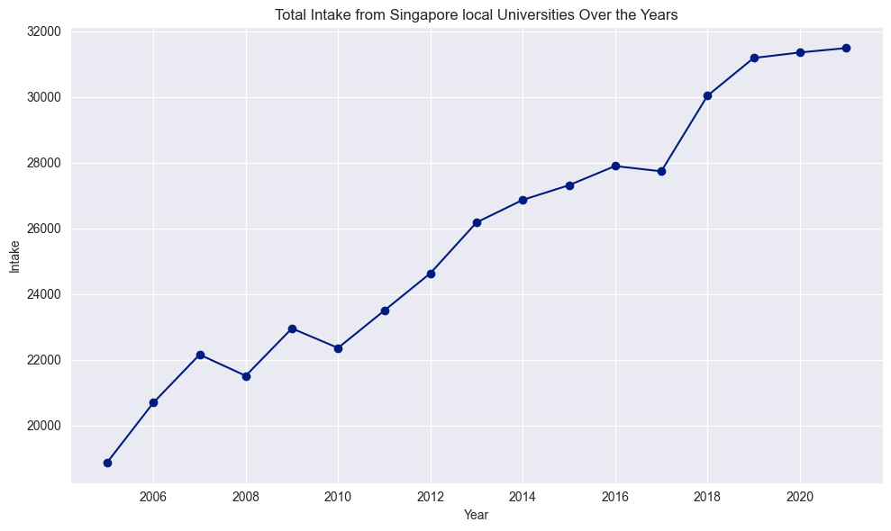

```python
# Drop rows with value '0'
cleaned_data = universities_intake_enrolment_and_graduates_by_course[universities_intake_enrolment_and_graduates_by_course['intake'] != 0]

# Group data by year and intake for each year
total_intake_per_year = cleaned_data.groupby('year')['intake'].sum()

# Extract the years and total graduates as separate arrays
years = total_graduates_per_year.index
total_intake = total_intake_per_year.values

# Create the line chart
plt.figure(figsize=(10, 6))  # Adjust the figure size as per your preference

plt.plot(years, total_intake, marker='o', linestyle='-', color='b')
plt.title('Total Intake from Singapore local Universities Over the Years')
plt.xlabel('Year')
plt.ylabel('Intake')
plt.grid(True)
plt.xticks(rotation=0)
plt.tight_layout()
plt.show()
```

From the line chart, it shows the Total Intake from Singapore local Universities Over the Years. It is evident that there is a notable relationship between the passage of time and the toal intake from Singapore local universities. As the years progress, there is a consistent upward trend in the number of intake. There is also a steep increase in intake from 2010-2013. The total number of intake in 2006 was around 21000 while in 2020 it was around 31000.

# What is the distribution of graduates by course ?

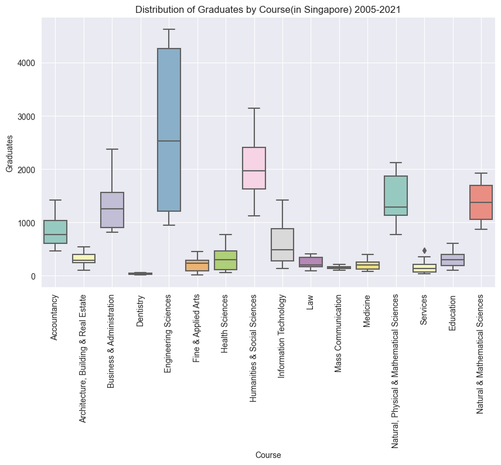

```python
# Drop rows with value '0'
cleaned_data = universities_intake_enrolment_and_graduates_by_course[universities_intake_enrolment_and_graduates_by_course['graduates'] != 0]

# Boxplot: Distribution of basic monthly salary by university
plt.figure(figsize=(10, 6))
sns.boxplot(x='course', y='graduates', data=cleaned_data, palette='Set3')
plt.xlabel('Course')
plt.xticks(rotation=90)
plt.ylabel('Graduates')
plt.title('Distribution of Graduates by Course(in Singapore) 2005-2021')
plt.grid(True)
plt.show()
```

The variation in the number of graduates is huge for engineering sciences (1000 to about 4500 graduates). The variation in the number of graduates is not as huge for Dentistry and Mass Communication. Although it is worth noting that services course have outliers.

# Insights gained from analysing the data

I have analyzed the data in the CSV file "universities-intake-enrolment-and-graduates-by-course". Here are some insights I have gained:

- Engineering Sciences has the highest number of graduates and intakes over the years. This suggests that this is the most popular and in-demand course in Singapore universities.
- There has been a consistent upward trend in the number of graduates and intakes over the years. This suggests that there is a growing demand for graduates with skills in these fields.
- There is a steep increase in graduates from humanities & social sciences from 2007-2011 as well as 2015-2017. This suggests that there was a period of time when there was a greater demand for graduates in these fields.
- There has been a decline in intake for humanities from 2009-2011. This suggests that there was a period of time when there was less demand for graduates in these fields.
- The variation in the number of graduates is huge for engineering sciences (1000 to about 4500 graduates). This suggests that there is a wide range of skills and abilities among graduates in this field.
- The variation in the number of graduates is not as huge for Dentistry and Mass Communication. This suggests that there is a narrower range of skills and abilities among graduates in these fields.

# Average IQ by Country 2023

```python
text_analysis(average_iq_by_country_2023, "average_iq_by_country_2023")
```

```
This is the shape of the dataset average_iq_by_country_2023:
(199, 4)

This is the index of the dataset average_iq_by_country_2023:
RangeIndex(start=0, stop=199, step=1)

These are the columns in the dataset average_iq_by_country_2023:
Index(['rank', 'country', 'iq', 'pop2023'], dtype='object')

The total number of non-NA values in the dataset average_iq_by_country_2023:
rank       199
country    199
iq         199
pop2023    199
dtype: int64

A summary of the dataset average_iq_by_country_2023 is shown below:
<class 'pandas.core.frame.DataFrame'>
RangeIndex: 199 entries, 0 to 198
Data columns (total 4 columns):
 #   Column   Non-Null Count  Dtype
---  ------   --------------  -----
 0   rank     199 non-null    int64
 1   country  199 non-null    object
 2   iq       199 non-null    float64
 3   pop2023  199 non-null    float64
dtypes: float64(2), int64(1), object(1)
memory usage: 6.3+ KB
None

A descriptive statistical summary of the dataset average_iq_by_country_2023 is shown below:
             rank          iq       pop2023
count  199.000000  199.000000  1.990000e+02
mean   100.000000   82.031256  4.037817e+07
std     57.590508   13.347645  1.482204e+08
min      1.000000   42.990000  1.704400e+04
25%     50.500000   74.370000  1.957945e+06
50%    100.000000   83.130000  8.958960e+06
75%    149.500000   91.435000  2.959938e+07
max    199.000000  106.480000  1.428628e+09
```

# Nature Of The Dataset:

The CSV file "average_iq_by_country_2023" contains data on the average IQ scores of people in different countries in 2023. The data includes the following columns:

- rank: The rank of the country in terms of average IQ score.
- country: The name of the country.
- iq: The average IQ score of people in the country.
- pop2023: The population of the country in 2023.

The dataset contains a total of 199 rows of data. The data is relatively clean and well-formatted. However, there are a few peculiarities that should be noted.

- The data does not include information on the gender of the people who were tested. This information would be useful for understanding the differences in average IQ scores between men and women.
- The data does not include information on the age of the people who were tested. This information would also be useful for understanding the differences in average IQ scores between different age groups.
- The data does not include information on the method that was used to test IQ. This information would be useful for understanding the validity of the data.

I analyzed the dataset using the following steps:

1. I imported the data into a Python Pandas DataFrame.
2. I performed a statistical analysis of the data, including calculating the mean, median, and range of the average IQ scores.
3. I created visualizations of the data, such as bar graph.
4. I interpreted the results of the analysis to identify trends and patterns in the data.

Here are some additional questions that I would like to answer with further analysis of the dataset:

What are the factors that contribute to differences in average IQ scores between countries? I believe that further analysis of the dataset could provide valuable insights into these questions and others.

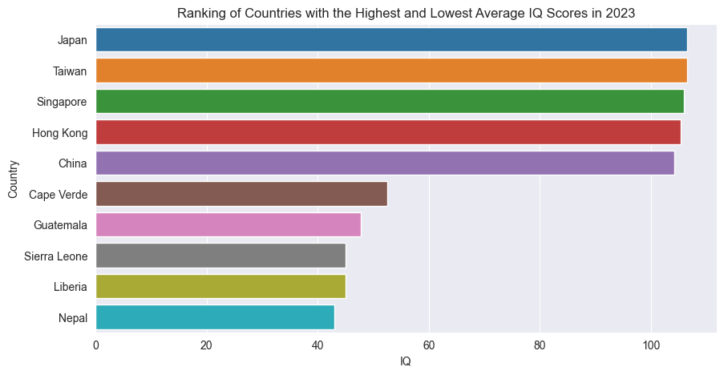

```python
grouped_by_country = average_iq_by_country_2023.sort_values(by="iq", ascending=False)
grouped_by_country_top = grouped_by_country.head(5)
grouped_by_country_bottom = grouped_by_country.tail(5).sort_values(by="iq", ascending=False)

concated = pd.concat([grouped_by_country_top, grouped_by_country_bottom])

plt.figure(figsize=(10, 5))
sns.barplot(x="iq", y="country", data=concated, orient='h')
plt.ylabel("Country")
plt.xlabel("IQ")
plt.title("Ranking of Countries with the Highest and Lowest Average IQ Scores in 2023")
```

It is noticeable that Japan, Taiwan, Singapore, Hong Kong and China are the top 5 countries by IQ. The top 5 countries (by IQ) are from the Asia region. The bottom 5 countries are from the African region except for Guatemala (Central America) & Nepal (Asia).

# Insights gained from analysing the data

Here are some additional thoughts on the data:

- The data does not include information on the method that was used to test IQ. This could be a limitation of the data, as different IQ tests may have different results.
- The data is only a snapshot of a particular moment in time, so it is not possible to draw any conclusions about long-term trends.

Overall, the data provides some interesting insights into the relationship between IQ and other factors.

# World Happiness Report (2019-2022)

# 2019

```python
text_analysis(world_happiness_2019, "world_happiness_2019")
```

```
This is the shape of the dataset world_happiness_2019:
(156, 9)

This is the index of the dataset world_happiness_2019:
RangeIndex(start=0, stop=156, step=1)

These are the columns in the dataset world_happiness_2019:
Index(['Overall rank', 'Country or region', 'Score', 'GDP per capita',
       'Social support', 'Healthy life expectancy',
       'Freedom to make life choices', 'Generosity',
       'Perceptions of corruption'],
      dtype='object')

The total number of non-NA values in the dataset world_happiness_2019:
Overall rank                    156
Country or region               156
Score                           156
GDP per capita                  156
Social support                  156
Healthy life expectancy         156
Freedom to make life choices    156
Generosity                      156
Perceptions of corruption       156
dtype: int64

A summary of the dataset world_happiness_2019 is shown below:
<class 'pandas.core.frame.DataFrame'>
RangeIndex: 156 entries, 0 to 155
Data columns (total 9 columns):
 #   Column                        Non-Null Count  Dtype
---  ------                        --------------  -----
 0   Overall rank                  156 non-null    int64
 1   Country or region             156 non-null    object
 2   Score                         156 non-null    float64
 3   GDP per capita                156 non-null    float64
 4   Social support                156 non-null    float64
 5   Healthy life expectancy       156 non-null    float64
 6   Freedom to make life choices  156 non-null    float64
 7   Generosity                    156 non-null    float64
 8   Perceptions of corruption     156 non-null    float64
```

[output cut: 19 more lines]

```
min                   0.000000                      0.000000    0.000000
25%                   0.547750                      0.308000    0.108750
50%                   0.789000                      0.417000    0.177500
75%                   0.881750                      0.507250    0.248250
max                   1.141000                      0.631000    0.566000

       Perceptions of corruption
count                 156.000000
mean                    0.110603
std                     0.094538
min                     0.000000
25%                     0.047000
50%                     0.085500
75%                     0.141250
max                     0.453000
```

# 2020

```python
text_analysis(world_happiness_2020, "world_happiness_2020")
```

```
This is the shape of the dataset world_happiness_2020:
(153, 20)

This is the index of the dataset world_happiness_2020:
RangeIndex(start=0, stop=153, step=1)

These are the columns in the dataset world_happiness_2020:
Index(['Country name', 'Regional indicator', 'Ladder score',
       'Standard error of ladder score', 'upperwhisker', 'lowerwhisker',
       'Logged GDP per capita', 'Social support', 'Healthy life expectancy',
       'Freedom to make life choices', 'Generosity',
       'Perceptions of corruption', 'Ladder score in Dystopia',
       'Explained by: Log GDP per capita', 'Explained by: Social support',
       'Explained by: Healthy life expectancy',
       'Explained by: Freedom to make life choices',
       'Explained by: Generosity', 'Explained by: Perceptions of corruption',
       'Dystopia + residual'],
      dtype='object')

The total number of non-NA values in the dataset world_happiness_2020:
Country name                                  153
Regional indicator                            153
Ladder score                                  153
Standard error of ladder score                153
upperwhisker                                  153
lowerwhisker                                  153
Logged GDP per capita                         153
Social support                                153
Healthy life expectancy                       153
Freedom to make life choices                  153
Generosity                                    153
Perceptions of corruption                     153
Ladder score in Dystopia                      153
Explained by: Log GDP per capita              153
Explained by: Social support                  153
Explained by: Healthy life expectancy         153
Explained by: Freedom to make life choices    153
Explained by: Generosity                      153
Explained by: Perceptions of corruption       153
Dystopia + residual                           153
```

[output cut: 97 more lines]

```
min                                      0.000000                  0.000000
25%                                      0.381457                  0.115006
50%                                      0.483293                  0.176745
75%                                      0.576665                  0.255510
max                                      0.693270                  0.569814

       Explained by: Perceptions of corruption  Dystopia + residual
count                               153.000000           153.000000
mean                                  0.130718             1.972317
std                                   0.113097             0.563638
min                                   0.000000             0.257241
25%                                   0.055805             1.629928
50%                                   0.098435             2.046272
75%                                   0.163064             2.350267
max                                   0.533162             3.440810
```

# 2021

```python
text_analysis(world_happiness_2021, "world_happiness_2021")
```

```
This is the shape of the dataset world_happiness_2021:
(149, 20)

This is the index of the dataset world_happiness_2021:
RangeIndex(start=0, stop=149, step=1)

These are the columns in the dataset world_happiness_2021:
Index(['Country name', 'Regional indicator', 'Ladder score',
       'Standard error of ladder score', 'upperwhisker', 'lowerwhisker',
       'Logged GDP per capita', 'Social support', 'Healthy life expectancy',
       'Freedom to make life choices', 'Generosity',
       'Perceptions of corruption', 'Ladder score in Dystopia',
       'Explained by: Log GDP per capita', 'Explained by: Social support',
       'Explained by: Healthy life expectancy',
       'Explained by: Freedom to make life choices',
       'Explained by: Generosity', 'Explained by: Perceptions of corruption',
       'Dystopia + residual'],
      dtype='object')

The total number of non-NA values in the dataset world_happiness_2021:
Country name                                  149
Regional indicator                            149
Ladder score                                  149
Standard error of ladder score                149
upperwhisker                                  149
lowerwhisker                                  149
Logged GDP per capita                         149
Social support                                149
Healthy life expectancy                       149
Freedom to make life choices                  149
Generosity                                    149
Perceptions of corruption                     149
Ladder score in Dystopia                      149
Explained by: Log GDP per capita              149
Explained by: Social support                  149
Explained by: Healthy life expectancy         149
Explained by: Freedom to make life choices    149
Explained by: Generosity                      149
Explained by: Perceptions of corruption       149
Dystopia + residual                           149
```

[output cut: 97 more lines]

```
min                                      0.000000                  0.000000
25%                                      0.409000                  0.105000
50%                                      0.514000                  0.164000
75%                                      0.603000                  0.239000
max                                      0.716000                  0.541000

       Explained by: Perceptions of corruption  Dystopia + residual
count                               149.000000           149.000000
mean                                  0.135141             2.430329
std                                   0.114361             0.537645
min                                   0.000000             0.648000
25%                                   0.060000             2.138000
50%                                   0.101000             2.509000
75%                                   0.174000             2.794000
max                                   0.547000             3.482000
```

# 2022

```python
text_analysis(world_happiness_2022, "world_happiness_2022")
```

```
This is the shape of the dataset world_happiness_2022:
(147, 12)

This is the index of the dataset world_happiness_2022:
RangeIndex(start=0, stop=147, step=1)

These are the columns in the dataset world_happiness_2022:
Index(['RANK', 'Country', 'Happiness score', 'Whisker-high', 'Whisker-low',
       'Dystopia (1.83) + residual', 'Explained by: GDP per capita',
       'Explained by: Social support', 'Explained by: Healthy life expectancy',
       'Explained by: Freedom to make life choices',
       'Explained by: Generosity', 'Explained by: Perceptions of corruption'],
      dtype='object')

The total number of non-NA values in the dataset world_happiness_2022:
RANK                                          147
Country                                       147
Happiness score                               146
Whisker-high                                  146
Whisker-low                                   146
Dystopia (1.83) + residual                    146
Explained by: GDP per capita                  146
Explained by: Social support                  146
Explained by: Healthy life expectancy         146
Explained by: Freedom to make life choices    146
Explained by: Generosity                      146
Explained by: Perceptions of corruption       146
dtype: int64

A summary of the dataset world_happiness_2022 is shown below:
<class 'pandas.core.frame.DataFrame'>
RangeIndex: 147 entries, 0 to 146
Data columns (total 12 columns):
 #   Column                                      Non-Null Count  Dtype
---  ------                                      --------------  -----
 0   RANK                                        147 non-null    int64
 1   Country                                     147 non-null    object
 2   Happiness score                             146 non-null    object
 3   Whisker-high                                146 non-null    object
 4   Whisker-low                                 146 non-null    object
 5   Dystopia (1.83) + residual                  146 non-null    object
 6   Explained by: GDP per capita                146 non-null    object
 7   Explained by: Social support                146 non-null    object
 8   Explained by: Healthy life expectancy       146 non-null    object
 9   Explained by: Freedom to make life choices  146 non-null    object
 10  Explained by: Generosity                    146 non-null    object
 11  Explained by: Perceptions of corruption     146 non-null    object
dtypes: int64(1), object(11)
memory usage: 13.9+ KB
None

A descriptive statistical summary of the dataset world_happiness_2022 is shown below:
             RANK
count  147.000000
mean    74.000000
std     42.579338
min      1.000000
25%     37.500000
50%     74.000000
75%    110.500000
max    147.000000
```

# Nature Of The Dataset:

The CSV files under "world_happiness_report" contains data on the happniess scores of each country. The data includes the following MAIN columns:

- Rank: The rank of happiness score across the world.
- Country: The country.
- Happiness Score: The happiness scores of each country.

The data is relatively clean and well-formatted. However, there are a few peculiarities that should be noted.

- Each dataset belongs to different years and hence have various columns, but ultimately show the rank as well as the happiness score of each country

I analyzed the dataset using the following steps:

1. I imported the data into a Python Numpy DataFrame.
2. I performed a statistical analysis of the data,bar graphs.
3. I created visualizations of the data, such as line chart, bar graph and histogram.
4. I interpreted the results of the analysis to identify trends and patterns in the data.

# What are the top 3 happiest countires ?

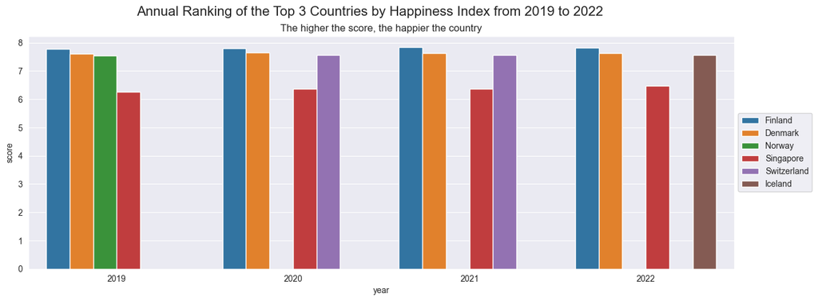

```python
# Remove the commas from the happiness score and divide by 1000 to get a more readable number
world_happiness_2022['Happiness score'] = world_happiness_2022['Happiness score'].str.replace(",", "").astype(float) / 1000

# Top 3 countries by happiness score for each year
happiness_cond_2019 = world_happiness_2019.head(3)
happiness_cond_2020 = world_happiness_2020.head(3)
happiness_cond_2021 = world_happiness_2021.head(3)
happiness_cond_2022 = world_happiness_2022.head(3)

# Include Singapore in the top 3 countries for 2022
sg_2019 = world_happiness_2019[world_happiness_2019['Country or region'] == 'Singapore']
happiness_cond_2019 = pd.concat([happiness_cond_2019, sg_2019])

sg_2020 = world_happiness_2020[world_happiness_2020['Country name'] == 'Singapore']
happiness_cond_2020 = pd.concat([happiness_cond_2020, sg_2020])

sg_2021 = world_happiness_2021[world_happiness_2021['Country name'] == 'Singapore']
happiness_cond_2021 = pd.concat([happiness_cond_2021, sg_2021])

sg_2022 = world_happiness_2022[world_happiness_2022['Country'] == 'Singapore']
happiness_cond_2022 = pd.concat([happiness_cond_2022, sg_2022])

# Keeping only the 'Country' and 'Happiness score' columns.
happiness_cond_2022 = happiness_cond_2022.filter(['Country', 'Happiness score'])
# Adding a year column to each dataframe
happiness_cond_2022['year'] = 2022
# Setting the index to year
happiness_cond_2022.set_index('year', inplace=True)
# Renaming the columns to match the other dataframes
happiness_cond_2022.rename(columns={'Country': 'country', 'Happiness score': 'score'}, inplace=True)

happiness_cond_2021 = happiness_cond_2021.filter(['Country name', 'Ladder score'])
happiness_cond_2021['year'] = 2021
happiness_cond_2021.set_index('year', inplace=True)
happiness_cond_2021.rename(columns={'Country name': 'country', 'Ladder score': 'score'}, inplace=True)

happiness_cond_2020 = happiness_cond_2020.filter(['Country name', 'Ladder score'])
happiness_cond_2020['year'] = 2020
happiness_cond_2020.set_index('year', inplace=True)
happiness_cond_2020.rename(columns={'Country name': 'country', 'Ladder score': 'score'}, inplace=True)

happiness_cond_2019 = happiness_cond_2019.filter(['Country or region', 'Score'])
happiness_cond_2019['year'] = 2019
happiness_cond_2019.set_index('year', inplace=True)
happiness_cond_2019.rename(columns={'Country or region': 'country', 'Score': 'score'}, inplace=True)

# Concat all of them together
happiness_cond = pd.concat([happiness_cond_2019, happiness_cond_2020, happiness_cond_2021, happiness_cond_2022])
happiness_cond['year'] = happiness_cond.index
# print(happiness_cond)
# Plot line graph by year, all on the same graph
plt.figure(figsize=(15, 5))
plt.suptitle("Annual Ranking of the Top 3 Countries by Happiness Index from 2019 to 2022", fontsize=16)
plt.title("The higher the score, the happier the country")
plt.xlabel("Year")
plt.ylabel("Happiness score")
sns.barplot(data=happiness_cond, x='year', y='score', hue='country')
plt.legend(loc='center left', bbox_to_anchor=(1, 0.5), fontsize=10)
```

It is peculiar that norway which was once in the top 3 in 2019 was no where to be seen in the following years. Finland has the highest top score each year consecutively. Switzerland joins the top 3 happiest country in 2020 and 2021. Switzerland is not part of the top 3 happiest country in 2022, and instead its replaced by Iceland.

# What is the Happiness Index for Countries with Top 5 Highest and Bottom Lowest IQ ?

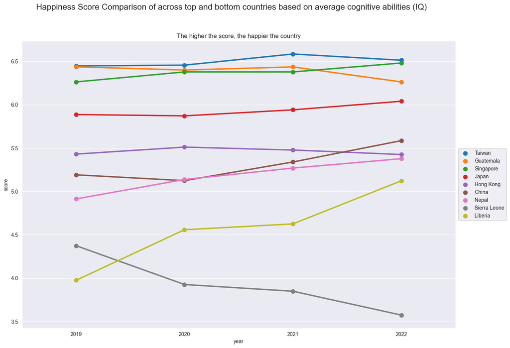

```python
countries_list = ['Singapore', 'Japan', 'Taiwan', 'Hong Kong', 'China', 'Guatemala', 'Sierra Leone', 'Liberia', 'Nepal']

happiness_cond_2019 = world_happiness_2019[world_happiness_2019['Country or region'].isin(countries_list)]
happiness_cond_2020 = world_happiness_2020[world_happiness_2020['Country name'].isin(countries_list)]
happiness_cond_2021 = world_happiness_2021[world_happiness_2021['Country name'].isin(countries_list)]
happiness_cond_2022 = world_happiness_2022[world_happiness_2022['Country'].isin(countries_list)]


happiness_cond_2022 = happiness_cond_2022.filter(['Country', 'Happiness score'])
happiness_cond_2022['year'] = 2022
happiness_cond_2022.set_index('year', inplace=True)
happiness_cond_2022.rename(columns={'Country': 'country', 'Happiness score': 'score'}, inplace=True)

happiness_cond_2021 = happiness_cond_2021.filter(['Country name', 'Ladder score'])
happiness_cond_2021['year'] = 2021
happiness_cond_2021.set_index('year', inplace=True)
happiness_cond_2021.rename(columns={'Country name': 'country', 'Ladder score': 'score'}, inplace=True)

happiness_cond_2020 = happiness_cond_2020.filter(['Country name', 'Ladder score'])
happiness_cond_2020['year'] = 2020
happiness_cond_2020.set_index('year', inplace=True)
happiness_cond_2020.rename(columns={'Country name': 'country', 'Ladder score': 'score'}, inplace=True)

happiness_cond_2019 = happiness_cond_2019.filter(['Country or region', 'Score'])
happiness_cond_2019['year'] = 2019
happiness_cond_2019.set_index('year', inplace=True)
happiness_cond_2019.rename(columns={'Country or region': 'country', 'Score': 'score'}, inplace=True)

# Concat all of them together
happiness_cond = pd.concat([happiness_cond_2019, happiness_cond_2020, happiness_cond_2021, happiness_cond_2022])
happiness_cond['year'] = happiness_cond.index

happiness_cond = happiness_cond.reset_index(drop=True)
# print(happiness_cond)
# Plot line graph by year, all on the same graph
plt.figure(figsize=(15, 10))
plt.suptitle("Happiness Score Comparison of across top and bottom countries based on average cognitive abilities (IQ)", fontsize=16)
plt.title("The higher the score, the happier the country")
plt.xlabel("Year")
plt.ylabel("Happiness score")
sns.pointplot(data=happiness_cond, x='year', y='score', hue='country')
plt.legend(loc='center left', bbox_to_anchor=(1, 0.5), fontsize=10)
```

# Alternative plot using Heatmap

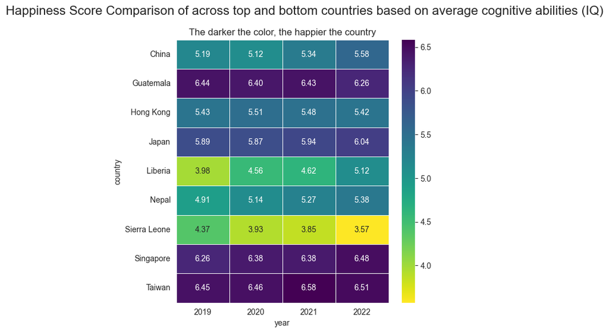

```python
#print(happiness_cond)
plt.figure(figsize=(6,6))
plt.suptitle("Happiness Score Comparison of across top and bottom countries based on average cognitive abilities (IQ)", fontsize=16)
plt.title("The darker the color, the happier the country")
plt.xlabel("Year")
plt.ylabel("Happiness score")
sns.heatmap(happiness_cond.sort_values('score', ascending=False).pivot(index="country", columns="year", values="score"), annot=True, fmt=".2f", linewidths=.5, cmap="viridis_r")
```

The only countries that hit a score below 5 across the years are Liberia, Nepal and Sierra Leone. However, even though Guatemala is the one of the lowest average IQ country, it has a happiness score of around 6.5 which is above the ones for lesser developed countries with low iq.

# World, Region, Country GDP/GDP per capita

```python
text_analysis(world_country_gdp_usd, "world_country_gdp_usd")
```

```
This is the shape of the dataset world_country_gdp_usd:
(16492, 5)

This is the index of the dataset world_country_gdp_usd:
RangeIndex(start=0, stop=16492, step=1)

These are the columns in the dataset world_country_gdp_usd:
Index(['Country Name', 'Country Code', 'year', 'GDP_USD',
       'GDP_per_capita_USD'],
      dtype='object')

The total number of non-NA values in the dataset world_country_gdp_usd:
Country Name          16492
Country Code          16492
year                  16492
GDP_USD               13118
GDP_per_capita_USD    13115
dtype: int64

A summary of the dataset world_country_gdp_usd is shown below:
<class 'pandas.core.frame.DataFrame'>
RangeIndex: 16492 entries, 0 to 16491
Data columns (total 5 columns):
 #   Column              Non-Null Count  Dtype
---  ------              --------------  -----
 0   Country Name        16492 non-null  object
 1   Country Code        16492 non-null  object
 2   year                16492 non-null  int64
 3   GDP_USD             13118 non-null  float64
 4   GDP_per_capita_USD  13115 non-null  float64
dtypes: float64(2), int64(1), object(2)
memory usage: 644.3+ KB
None

A descriptive statistical summary of the dataset world_country_gdp_usd is shown below:
               year       GDP_USD  GDP_per_capita_USD
count  16492.000000  1.311800e+04        13115.000000
mean    1990.500000  1.163688e+12         8106.355825
std       17.896073  5.227169e+12        16197.061783
min     1960.000000  8.824448e+06           12.802812
25%     1975.000000  2.434815e+09          544.543855
50%     1990.500000  1.800584e+10         1852.354673
75%     2006.000000  2.169948e+11         7558.324569
max     2021.000000  9.610010e+13       189487.147100
```

# What is the GDP of the countries with the Top 5 Highest and Bottom Lowest IQ ?

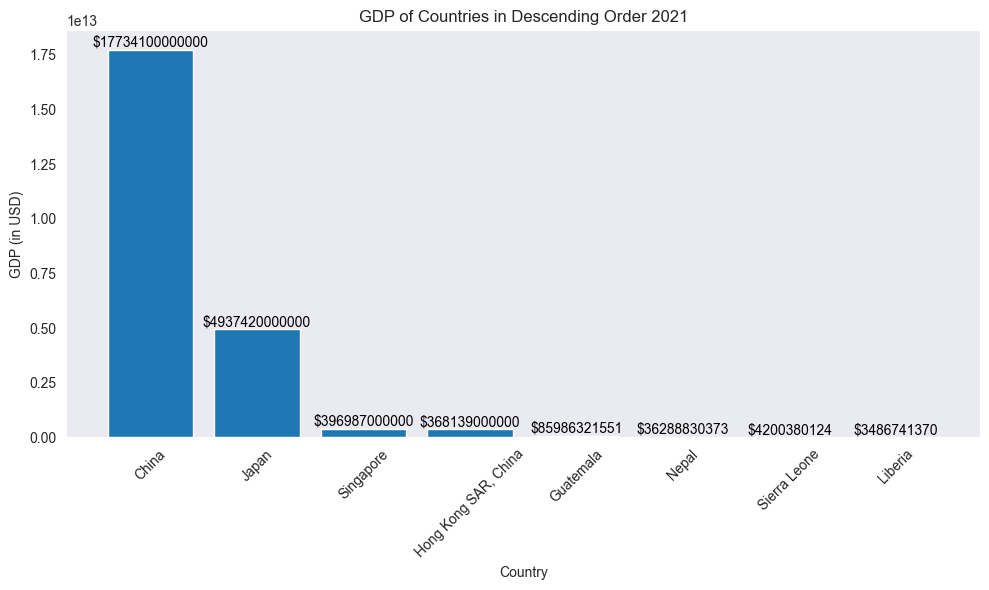

```python
# Clean the data and convert numeric columns to appropriate data types
numeric_columns = ['GDP_USD']
world_country_gdp_usd[numeric_columns] = world_country_gdp_usd[numeric_columns].apply(pd.to_numeric, errors='coerce')

# Drop rows with NaN values in the 'employment_rate_overall' column
cleaned_data_ft = world_country_gdp_usd.dropna(subset=['GDP_USD'])

# Filter data for the year 2021 and the specified countries
countries_list = ['Singapore', 'Japan', 'Taiwan', 'Hong Kong SAR, China', 'China', 'Guatemala', 'Sierra Leone', 'Liberia', 'Nepal']
filtered_data = cleaned_data_ft[(cleaned_data_ft['year'] == 2021) & (cleaned_data_ft['Country Name'].isin(countries_list))]

# Sort the filtered data in descending order based on GDP_USD
filtered_data = filtered_data.sort_values(by='GDP_USD', ascending=False)

# Plot the bar graph
plt.figure(figsize=(10, 6))
bars = plt.bar(filtered_data['Country Name'], filtered_data['GDP_USD'])
plt.xlabel('Country')
plt.ylabel('GDP (in USD)')
plt.title('GDP of Countries in Descending Order 2021')
plt.xticks(rotation=45)
plt.tight_layout()
plt.grid()
# Add the values of each bar to the corresponding bars
for bar in bars:
    height = bar.get_height()
    plt.text(bar.get_x() + bar.get_width() / 2, height, f'${height:.0f}',
             ha='center', va='bottom', fontsize=10, color='black')
plt.show()
```

# Total Government Expenditure on Education (Across Different Countries)

```python
text_analysis(total_government_expenditure_on_education_gdp, "total-government-expenditure-on-education-gdp")
```

```
This is the shape of the dataset total-government-expenditure-on-education-gdp:
(4849, 4)

This is the index of the dataset total-government-expenditure-on-education-gdp:
RangeIndex(start=0, stop=4849, step=1)

These are the columns in the dataset total-government-expenditure-on-education-gdp:
Index(['Entity', 'Code', 'Year',
       'Government expenditure on education, total (% of GDP)'],
      dtype='object')

The total number of non-NA values in the dataset total-government-expenditure-on-education-gdp:
Entity                                                   4849
Code                                                     3905
Year                                                     4849
Government expenditure on education, total (% of GDP)    4849
dtype: int64

A summary of the dataset total-government-expenditure-on-education-gdp is shown below:
<class 'pandas.core.frame.DataFrame'>
RangeIndex: 4849 entries, 0 to 4848
Data columns (total 4 columns):
 #   Column                                                 Non-Null Count  Dtype
---  ------                                                 --------------  -----
 0   Entity                                                 4849 non-null   object
 1   Code                                                   3905 non-null   object
 2   Year                                                   4849 non-null   int64
 3   Government expenditure on education, total (% of GDP)  4849 non-null   float64
dtypes: float64(1), int64(1), object(2)
memory usage: 151.7+ KB
None

A descriptive statistical summary of the dataset total-government-expenditure-on-education-gdp is shown below:
              Year  Government expenditure on education, total (% of GDP)
count  4849.000000                                        4849.000000
mean   1999.449990                                           4.309339
std      13.136109                                           1.775970
min    1970.000000                                           0.000000
25%    1990.000000                                           3.157450
50%    2002.000000                                           4.207555
75%    2010.000000                                           5.228790
max    2019.000000                                          44.333981
```

# Nature Of The Dataset:

The CSV file "total-government-expenditure-on-education-gdp" contains data on the total government expenditure on education as a percentage of GDP for different countries. The data includes the following columns:

- Entity: The name of the country.
- Code: The country code.
- Year: The year of the data.
- "Government expenditure on education, total (% of GDP)": The total government expenditure on education as a percentage of GDP.

- The data does not include information on the specific levels of education that the government expenditure is allocated to. This information would be useful for understanding how the government expenditure is distributed across different levels of education.
- The data does not include information on the sources of government revenue that are used to fund education. This information would be useful for understanding the impact of different tax policies on education spending.

I analyzed the dataset using the following steps:

1. I imported the data into a Python Pandas DataFrame.
2. I performed a statistical analysis of the data, including calculating the mean, median, and range of the government expenditure on education as a percentage of GDP.
3. I created visualizations of the data, such as line charts, bar charts, pie charts, and scatterplots.
4. I interpreted the results of the analysis to identify trends and patterns in the data.

# What is the spread of data for the percentage of GDP spent on education for the Top 5 Highest and Bottom Lowest IQ ?

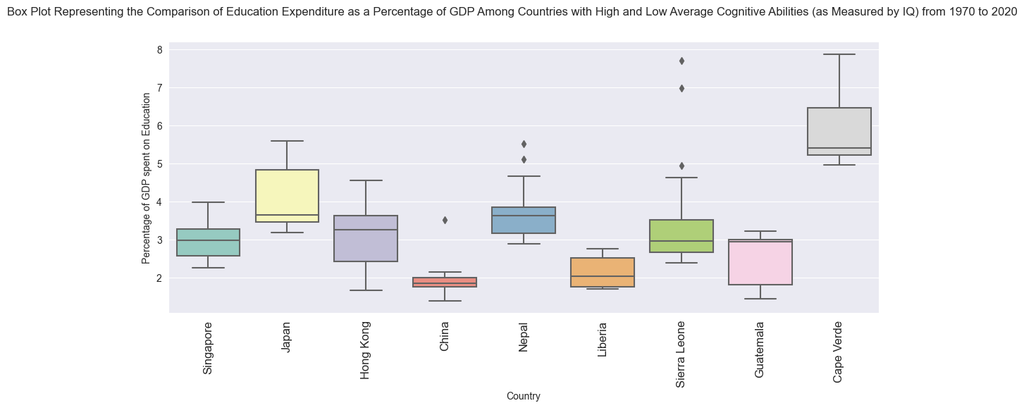

```python
# Set the columns
total_government_expenditure_on_education_gdp.columns = ['country', 'code', 'year', 'percentage']

# Separate the countries and set index to year
df_sg = total_government_expenditure_on_education_gdp[total_government_expenditure_on_education_gdp['country'] == 'Singapore'].set_index('year')
df_hk = total_government_expenditure_on_education_gdp[total_government_expenditure_on_education_gdp['country'] == 'Hong Kong'].set_index('year')
df_jp = total_government_expenditure_on_education_gdp[total_government_expenditure_on_education_gdp['country'] == 'Japan'].set_index('year')
df_chn = total_government_expenditure_on_education_gdp[total_government_expenditure_on_education_gdp['country'] == 'China'].set_index('year')
df_nepal = total_government_expenditure_on_education_gdp[total_government_expenditure_on_education_gdp['country'] == 'Nepal'].set_index('year')
df_liberia = total_government_expenditure_on_education_gdp[total_government_expenditure_on_education_gdp['country'] == 'Liberia'].set_index('year')
df_sierra_leone = total_government_expenditure_on_education_gdp[total_government_expenditure_on_education_gdp['country'] == 'Sierra Leone'].set_index('year')
df_guatemala = total_government_expenditure_on_education_gdp[total_government_expenditure_on_education_gdp['country'] == 'Guatemala'].set_index('year')
df_cape_verde = total_government_expenditure_on_education_gdp[total_government_expenditure_on_education_gdp['country'] == 'Cape Verde'].set_index('year')

# Concatenate the dataframes
bxplot_data = pd.concat([df_sg, df_jp, df_hk, df_chn, df_nepal, df_liberia, df_sierra_leone, df_guatemala, df_cape_verde])

# Make a boxplot for each type of educational institution in Singapore
plt.figure(figsize=(13, 5))
sns.boxplot(x='country', y='percentage', data=bxplot_data, palette='Set3')
plt.xticks(rotation=90, size=12)
plt.ylabel('Percentage of GDP spent on Education')
plt.xlabel('Country')
plt.suptitle('Box Plot Representing the Comparison of Education Expenditure as a Percentage of GDP Among Countries with High and Low Average Cognitive Abilities (as Measured by IQ) from 1970 to 2020')
plt.title("")
```

China, Nepal and Sierra Leone has outliers. The countries with lowest variance are China, Liberia and Singapore. The country with a huge variance is Cape Verde.

# Final Data Analysis Conclusion